# Identification of Oncofetal PIWI-interacting RNAs as Potential Prognostic Biomarkers in Lung Adenocarcinoma

Vanessa G. P. Souza

## Introduction

# **LUAD piRNA Analysis**

### Load Libraries

```r
library(DT)                      # For creating interactive tables
library(readxl)                  # For reading Excel files
library(pheatmap)                # For generating heatmaps
library(ggplot2)                 # For saving and customizing plots
library(gridExtra)               # For arranging multiple plots
library(UpSetR)                  # For upset plot
```

### Load Data

In this section, we load the LUAD data, which contains piRNA expression data across different sample types (ANL and tumor).

```r
TCGA_LUAD_paired_nofetal <- read_excel("TCGA_LUAD_paired_nofetal.xls")
head(TCGA_LUAD_paired_nofetal)  # Preview the first few rows to confirm data loading
```

```
## # A tibble: 6 × 93
##   piRNAs       LUAD_ANL_1 LUAD_ANL_2 LUAD_ANL_3 LUAD_ANL_4 LUAD_ANL_5 LUAD_ANL_6
##   <chr>             <dbl>      <dbl>      <dbl>      <dbl>      <dbl>      <dbl>
## 1 URS000000AA…      0.234      0.583      0.640      0          0.648      1.43
## 2 URS000002DD…      0          0          0.160      0          0          0
## 3 URS00000508…      0          0          0          0          0          0.714
## 4 URS00000663…      0          0          0          0          0          0
## 5 URS000006A0…      0.234      0.389      0.160      0.336      0          0.714
## 6 URS00000866…      0          0          0.160      0          0          0.714
## # ℹ 86 more variables: LUAD_ANL_7 <dbl>, LUAD_ANL_8 <dbl>, LUAD_ANL_9 <dbl>,
## #   LUAD_ANL_10 <dbl>, LUAD_ANL_11 <dbl>, LUAD_ANL_12 <dbl>, LUAD_ANL_13 <dbl>,
## #   LUAD_ANL_14 <dbl>, LUAD_ANL_15 <dbl>, LUAD_ANL_16 <dbl>, LUAD_ANL_17 <dbl>,
## #   LUAD_ANL_18 <dbl>, LUAD_ANL_19 <dbl>, LUAD_ANL_20 <dbl>, LUAD_ANL_21 <dbl>,
## #   LUAD_ANL_22 <dbl>, LUAD_ANL_23 <dbl>, LUAD_ANL_24 <dbl>, LUAD_ANL_25 <dbl>,
## #   LUAD_ANL_26 <dbl>, LUAD_ANL_27 <dbl>, LUAD_ANL_28 <dbl>, LUAD_ANL_29 <dbl>,
## #   LUAD_ANL_30 <dbl>, LUAD_ANL_31 <dbl>, LUAD_ANL_32 <dbl>, …
```

### Filter and Identify piRNAs

The following steps involve filtering piRNAs based on their expression in the tumor and ANL groups and classifying them as either exclusive to the tumor group, exclusive to the ANL group, or shared between both groups. piRNAs were considered ‘expressed’ if detected at ≥ 1 RPM in at least 10% of samples within each tissue type. piRNAs that did not meet this criterion were classified as ‘non-expressed’.

```r
# 1. Define groups
group_samples_anl <- grep("LUAD_ANL", colnames(TCGA_LUAD_paired_nofetal))  # ANL samples
group_samples_tumor <- grep("LUAD_Tumor", colnames(TCGA_LUAD_paired_nofetal))  # Tumor samples

# 2. Function to check expression threshold (piRNAs expressed in at least 10% of samples with count >= 1)
is_expressed <- function(data, threshold_rpm = 1, threshold_percent = 0.1) {
  expressed_samples <- data >= threshold_rpm
  expressed_percentage <- sum(expressed_samples) / length(data)
  return(expressed_percentage >= threshold_percent)
}

# 3. Apply the function to filter expressed piRNAs in both groups
expressed_in_anl <- apply(TCGA_LUAD_paired_nofetal[, group_samples_anl], 1, is_expressed)
expressed_in_tumor <- apply(TCGA_LUAD_paired_nofetal[, group_samples_tumor], 1, is_expressed)

# 4. Get piRNA names
piRNA_names <- TCGA_LUAD_paired_nofetal$piRNAs

# 5. Classify piRNAs into exclusive and shared groups
exclusive_in_tumor <- piRNA_names[expressed_in_tumor & !expressed_in_anl]
exclusive_in_anl <- piRNA_names[expressed_in_anl & !expressed_in_tumor]
shared_between_groups <- piRNA_names[expressed_in_anl & expressed_in_tumor]
```

### Tables of piRNAs

We will now create a data frame to display the piRNAs categorized into tumor-exclusive, ANL-exclusive, and shared piRNAs.

```r
# 6. Create a data frame for piRNAs and their group classifications
piRNA_results <- data.frame(
  piRNA = c(exclusive_in_tumor, exclusive_in_anl, shared_between_groups),
  Group = c(rep("Tumor", length(exclusive_in_tumor)),
            rep("Normal", length(exclusive_in_anl)),
            rep("Shared", length(shared_between_groups)))
)

# 7. Display the table interactively within the R Markdown
datatable(piRNA_results, options = list(pageLength = 10))  # This will display the table
```

|  | piRNA | Group |
| --- | --- | --- |
| 1 | URS000000AA0C\|piR-49039 | Tumor |
| 2 | URS000002DD41\|piR-36026 | Tumor |
| 3 | URS00000508D0\|piR-34021 | Tumor |
| 4 | URS0000066313\|piR-38252 | Tumor |
| 5 | URS000006A033\|piR-44717 | Tumor |
| 6 | URS000008666A\|piR-45884 | Tumor |
| 7 | URS00000B383E\|piR-44719 | Tumor |
| 8 | URS00000B8F4E\|piR-33519 | Tumor |
| 9 | URS00000C8761\|piR-35462 | Tumor |
| 10 | URS00000EDB82\|piR-38574 | Tumor |

[output cut: 425 more lines]

### Heatmap of Tumor-Specific piRNAs

In this step, we generate a heatmap to visualize the expression of tumor-specific piRNAs across the samples. The heatmap will differentiate tumor and ANL samples using color annotations.

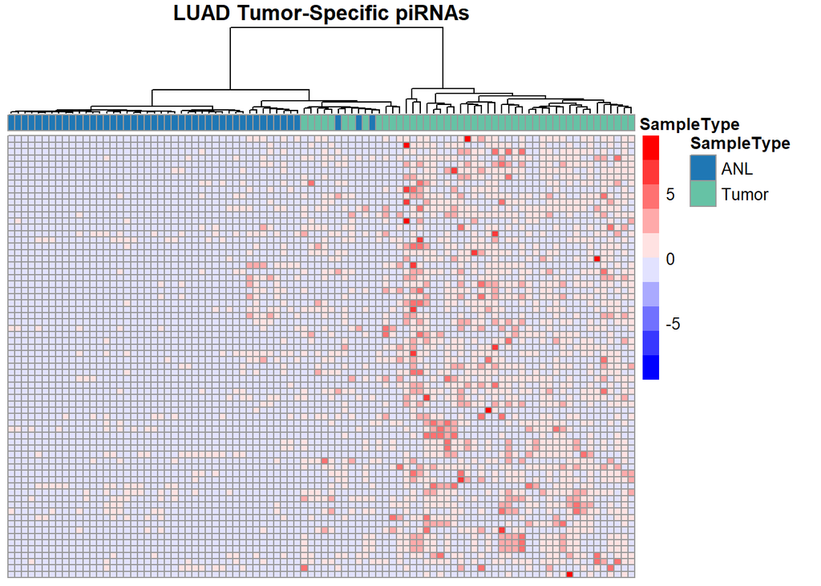

```r
# 8. Subset expression data for piRNAs exclusive to tumor
exclusive_in_tumor_data <- TCGA_LUAD_paired_nofetal[expressed_in_tumor & !expressed_in_anl, -1]

# 9. Define annotation for sample types (ANL and tumor)
sample_types <- ifelse(grepl("^LUAD_Tumor", colnames(exclusive_in_tumor_data)), "Tumor", "ANL")
annotation_col <- data.frame(SampleType = factor(sample_types, levels = c("ANL", "Tumor")))
rownames(annotation_col) <- colnames(exclusive_in_tumor_data)
annotation_colors <- list(SampleType = c("ANL" = "#1f77b4", "Tumor" = "#66c2a5"))

# 10. Generate and show heatmap in the R Markdown document
pheatmap(exclusive_in_tumor_data,
         cluster_rows = F,          # Do not cluster piRNAs
         cluster_cols = T,          # Cluster samples (tumor vs normal)
         show_rownames = F,         # Do not display piRNA names
         show_colnames = F,         # Do not display sample names
         scale = "row",             # Normalize by row (piRNA)
         color = colorRampPalette(c("blue", "white", "red"))(10),  # Color gradient from blue to red
         main = "LUAD Tumor-Specific piRNAs",  # Title
         annotation_col = annotation_col,  # Add sample type annotation
         annotation_colors = annotation_colors,  # Color scheme for annotations
         clustering_distance_cols = "euclidean",  # Euclidean distance for column clustering
         clustering_method = "ward.D")  # Agglomerative clustering method
```

### Save Results as Files

Here, we save the results of the filtered piRNAs and their classifications as text files for further analysis.

```r
# 11. Save piRNA classification results to text files
write.table(exclusive_in_tumor, file = "expressed_in_tumor_LUAD.txt", sep = "   ", row.names = FALSE, quote = FALSE)
write.table(exclusive_in_anl, file = "expressed_in_ANL_LUAD.txt", sep = "   ", row.names = FALSE, quote = FALSE)
write.table(shared_between_groups, file = "shared_piRNAs_LUAD.txt", sep = " ", row.names = FALSE, quote = FALSE)
```

### Visualize and Save the Heatmap

In this section, the heatmap plot will be saved as a PNG file for publication or presentation purposes.

```r
# 12. Save the heatmap as a PNG file
ggsave(filename = "heatmap_piRNAs_LUAD.png", plot = last_plot(), dpi = 600, width = 5, height = 4)
```

# **LUSC piRNA Analysis**

In this section, we load the LUSC data, which contains piRNA expression data across different sample types (ANL and tumor).

```r
### Load Data
TCGA_LUSC_paired_nofetal <- read_excel("TCGA_LUSC_paired_nofetal.xls")
head(TCGA_LUSC_paired_nofetal)  # Preview the first few rows to confirm data loading
```

```
## # A tibble: 6 × 91
##   piRNAs       LUSC_ANL_1 LUSC_ANL_2 LUSC_ANL_3 LUSC_ANL_4 LUSC_ANL_5 LUSC_ANL_6
##   <chr>             <dbl>      <dbl>      <dbl>      <dbl>      <dbl>      <dbl>
## 1 URS0000002D…      145.        79.3   113.        416.         45.1      187.
## 2 URS00000033…       55.5       27.6    30.0        41.9        18.7       31.4
## 3 URS0000009A…       34.0       10.8    30.3        92.4        14.6      105.
## 4 URS000000AA…        0          0       0.0857      0.844       0          3.56
## 5 URS000000E7…       99.8       13.0    23.2        97.9         8.69      11.7
## 6 URS000000F7…      319.       110.    226.        191.        171.       363.
## # ℹ 84 more variables: LUSC_ANL_7 <dbl>, LUSC_ANL_8 <dbl>, LUSC_ANL_9 <dbl>,
## #   LUSC_ANL_10 <dbl>, LUSC_ANL_11 <dbl>, LUSC_ANL_12 <dbl>, LUSC_ANL_13 <dbl>,
## #   LUSC_ANL_14 <dbl>, LUSC_ANL_15 <dbl>, LUSC_ANL_16 <dbl>, LUSC_ANL_17 <dbl>,
## #   LUSC_ANL_18 <dbl>, LUSC_ANL_19 <dbl>, LUSC_ANL_20 <dbl>, LUSC_ANL_21 <dbl>,
## #   LUSC_ANL_22 <dbl>, LUSC_ANL_23 <dbl>, LUSC_ANL_24 <dbl>, LUSC_ANL_25 <dbl>,
## #   LUSC_ANL_26 <dbl>, LUSC_ANL_27 <dbl>, LUSC_ANL_28 <dbl>, LUSC_ANL_29 <dbl>,
## #   LUSC_ANL_30 <dbl>, LUSC_ANL_31 <dbl>, LUSC_ANL_32 <dbl>, …
```

### Filter and Identify piRNAs

The following steps involve filtering piRNAs based on their expression in the tumor and ANL groups and classifying them as either exclusive to the tumor group, exclusive to the ANL group, or shared between both groups. piRNAs were considered ‘expressed’ if detected at ≥ 1 RPM in at least 10% of samples within each tissue type. piRNAs that did not meet this criterion were classified as ‘non-expressed’.

```r
# 1. Define groups
group_samples_anl <- grep("LUSC_ANL", colnames(TCGA_LUSC_paired_nofetal))
group_samples_tumor <- grep("LUSC_Tumor", colnames(TCGA_LUSC_paired_nofetal))

# 2. Function to check expression threshold (piRNAs expressed in at least 10% of samples with count >= 1)
is_expressed <- function(data, threshold_rpm = 1, threshold_percent = 0.1) {
  expressed_samples <- data >= threshold_rpm
  expressed_percentage <- sum(expressed_samples) / length(data)
  return(expressed_percentage >= threshold_percent)
}

# 3. Apply the function to filter expressed piRNAs in both groups
expressed_in_anl <- apply(TCGA_LUSC_paired_nofetal[, group_samples_anl], 1, is_expressed)
expressed_in_tumor <- apply(TCGA_LUSC_paired_nofetal[, group_samples_tumor], 1, is_expressed)

# 4. piRNAs names
piRNA_names <- TCGA_LUSC_paired_nofetal$piRNAs

# 5. Classify piRNAs into exclusive and shared groups
exclusive_in_tumor <- piRNA_names[expressed_in_tumor & !expressed_in_anl]
exclusive_in_anl <- piRNA_names[expressed_in_anl & !expressed_in_tumor]
shared_between_groups <- piRNA_names[expressed_in_anl & expressed_in_tumor]

expressed_in_tumor_3 <- as.data.frame(piRNA_names[expressed_in_tumor])
expressed_in_anl_3 <- as.data.frame(piRNA_names[expressed_in_anl])
```

```r
# 6. Create a data frame for piRNAs and their group classifications
piRNA_results <- data.frame(
  piRNA = c(exclusive_in_tumor, exclusive_in_anl, shared_between_groups),
  Group = c(rep("Tumor", length(exclusive_in_tumor)),
            rep("Normal", length(exclusive_in_anl)),
            rep("Shared", length(shared_between_groups)))
)

# 7. Display the table interactively within the R Markdown
datatable(piRNA_results, options = list(pageLength = 10))  # This will display the table
```

|  | piRNA | Group |
| --- | --- | --- |
| 1 | URS0000001B02\|piR-34342 | Tumor |
| 2 | URS000003587D\|piR-34789 | Tumor |
| 3 | URS000003B4AC\|piR-33127 | Tumor |
| 4 | URS00000508D0\|piR-34021 | Tumor |
| 5 | URS0000066313\|piR-38252 | Tumor |
| 6 | URS0000067282\|piR-32148 | Tumor |
| 7 | URS000007540B\|piR-30112 | Tumor |
| 8 | URS00000EDB82\|piR-38574 | Tumor |
| 9 | URS000011C1E6\|piR-55151 | Tumor |
| 10 | URS000011FF8D\|piR-34929 | Tumor |

[output cut: 396 more lines]

### Heatmap of Tumor-Specific piRNAs

In this step, we generate a heatmap to visualize the expression of tumor-specific piRNAs across the samples. The heatmap will differentiate tumor and ANL samples using color annotations.

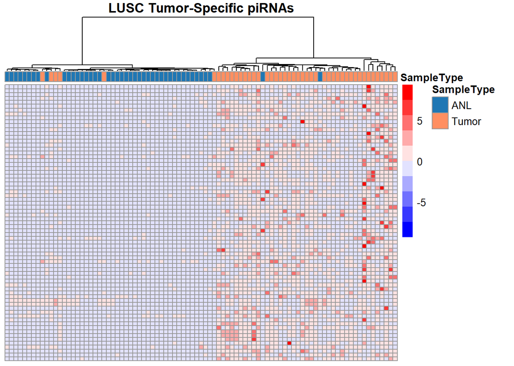

```r
# 8. Subset expression data for piRNAs exclusive to tumor
exclusive_in_tumor_data <- TCGA_LUSC_paired_nofetal[expressed_in_tumor & !expressed_in_anl, -1]
expression_data_heat <- exclusive_in_tumor_data[, -1]  # Assumindo que a primeira coluna é 'piRNAs'

# 9. Define annotation for sample types (ANL and tumor)
sample_types <- ifelse(grepl("^LUSC_Tumor", colnames(expression_data_heat)), "Tumor", "ANL")
sample_types <- factor(sample_types, levels = c("ANL", "Tumor"))
annotation_col <- data.frame(SampleType = sample_types)
rownames(annotation_col) <- colnames(expression_data_heat)
annotation_colors <- list(SampleType = c("ANL" = "#1f77b4", "Tumor" = "#FF8F61"))

# 10. Generate and show heatmap in the R Markdown document
save3 <- pheatmap(expression_data_heat,
         cluster_rows = F,
         cluster_cols = T,
         show_rownames = F,
         show_colnames = F,
         scale = "row",
         color = colorRampPalette(c("blue", "white", "red"))(10),
         main = "LUSC Tumor-Specific piRNAs",
         annotation_col = annotation_col,
         annotation_colors = annotation_colors,
         clustering_distance_cols = "euclidean",
         clustering_method = "ward.D")
```

### Save Results as Files

Here, we save the results of the filtered piRNAs and their classifications as text files for further analysis.

```r
# 11. Save piRNA classification results to text files
write.table(exclusive_in_tumor, file = "expressed_in_tumor_LUSC.txt", sep = "   ", row.names = FALSE, quote = FALSE)
write.table(exclusive_in_anl, file = "expressed_in_ANL_LUSC.txt", sep = "   ", row.names = FALSE, quote = FALSE)
write.table(shared_between_groups, file = "shared_piRNAs_LUSC.txt", sep = " ", row.names = FALSE, quote = FALSE)
```

### Visualize and Save the Heatmap

In this section, the heatmap plot will be saved as a PNG file for publication or presentation purposes.

```r
# 12. Save the heatmap as a PNG file
ggsave(filename = "Figure_3.png", plot = last_plot(), dpi = 600, width = 5, height = 4)
```

# **Fetal piRNA Analysis**

### 1. Load and Read Fetal Samples Data

```r
# Reading the piRNA count data from a text file
# Make sure the file path is correct. Consider using relative paths for better portability
fetal_samples_counts <- read.delim("C:/Users/User/OneDrive/Área de Trabalho/Michelle paper/fetal_samples_counts.txt", row.names=1)
```

### 2. Data Filtering: piRNAs > 1 RPM Expressed in at Least 10% of Samples

```r
# Number of total samples (columns in the dataset)
total_samples <- ncol(fetal_samples_counts)

# Define the minimum number of samples for expression (at least 10% of the total samples)
min_samples <- ceiling(total_samples * 0.10)  # Round up to the nearest integer

# Filter piRNAs that are expressed (count >= 1) in at least 10% of the samples
filtered_df <- fetal_samples_counts[rowSums(fetal_samples_counts >= 1) >= min_samples, ]

# Display the table interactively
datatable(filtered_df, options = list(pageLength = 10))
```

|  | MX0615.D0L5RACXX.1.ATTGGC | MX0615.D0L5RACXX.1.CTGATC | MX0615.D0L5RACXX.1.GATCTG | MX0615.D0L5RACXX.1.TCAAGT | MX0615.D0L5RACXX.1.TGGTCA | MX1303.C5JC4ACXX.3.AGGAAT | MX1304.C5JC4ACXX.4.CGCCTG | MX1305.C5JC4ACXX.5.CCACTC | MX1306.C5JC4ACXX.6.TTATTC | MX1307.C5JC4ACXX.7.TAAGGC | MX1308.C5JC1ACXX.2.ATTATA | MX1309.C5JC1ACXX.3.AAACCT | MX1309.C5JC1ACXX.3.CATTCA | MX1309.C5JC1ACXX.3.TTCGAA | MX1309.C5JC1ACXX.3.TTGACT | MX1354.C6RGTANXX.1.AGCGCT | MX1354.C6RGTANXX.1.AGCTAG | MX1354.C6RGTANXX.1.CGTGAT | MX1354.C6RGTANXX.1.CTGATC | MX1354.C6RGTANXX.1.CTGGGT | MX1354.C6RGTANXX.1.CTTTTG | MX1354.C6RGTANXX.1.GGGGTT | MX1354.C6RGTANXX.1.TGTTGG | MX1355.C6RGTANXX.2.AGCATC | MX1355.C6RGTANXX.2.CGATTA |
| --- | --- | --- | --- | --- | --- | --- | --- | --- | --- | --- | --- | --- | --- | --- | --- | --- | --- | --- | --- | --- | --- | --- | --- | --- | --- |
| URS0000002D9E\|piR-36743 | 1212.88 | 250.171 | 182.803 | 448.61 | 336.796 | 695.258 | 1311.68 | 840.289 | 1306.55 | 390.313 | 383.482 | 393.879 | 2095.59 | 1371.83 | 1056.39 | 1609.93 | 1281.81 | 308.334 | 1685.48 | 1725.77 | 867.409 | 426.439 | 2363.52 | 1151.93 | 249.877 |
| URS00000033F3\|piR-31447 | 7.04445 | 6.38528 | 24.3048 | 20.3675 | 29.647 | 70.7015 | 114.735 | 94.292 | 56.1457 | 117.82 | 22.5515 | 68.6945 | 86.7024 | 52.0941 | 74.2781 | 118.115 | 198.298 | 137.425 | 86.319 | 142.51 | 143.239 | 188.487 | 62.919 | 201.942 | 279.054 |
| URS0000009A89\|piR-34358 | 22.587 | 15.4211 | 44.5372 | 15.8006 | 15.5673 | 36.2776 | 77.4103 | 73.2847 | 73.6169 | 21.6889 | 63.7626 | 29.0246 | 66.9252 | 89.432 | 48.5311 | 391.694 | 160.957 | 2923.04 | 224.97 | 318.412 | 160.246 | 130.946 | 111.841 | 491.069 | 206.061 |
| URS000000E79F\|piR-33081 | 31.7932 | 142.163 | 35.94 | 40.6825 | 41.8671 | 60.9039 | 73.2176 | 82.8529 | 101.69 | 25.8366 | 67.068 | 45.584 | 66.049 | 127.441 | 138.084 | 45.7945 | 62.6648 | 24.2761 | 27.9765 | 68.7757 | 97.1683 | 31.5828 | 40.0001 | 37.2993 | 21.1956 |
| URS000000F7BE\|piR-61267 | 45.5094 | 80.7799 | 62.5718 | 60.5776 | 58.922 | 211.31 | 53.5838 | 105.143 | 52.143 | 127.973 | 86.634 | 131.293 | 59.4566 | 57.3482 | 59.821 | 109.405 | 159.047 | 158.771 | 96.8332 | 104.968 | 112.21 | 214.445 | 53.831 | 121.852 | 93.7468 |
| URS000001545A\|piR-31368 | 20.7979 | 8.85506 | 4.91266 | 12.1785 | 7.70396 | 13.3459 | 24.3377 | 29.3994 | 28.5056 | 6.00549 | 5.2247 | 7.91579 | 22.2806 | 29.0095 | 12.2094 | 45.2666 | 25.535 | 17.9978 | 33.3071 | 37.8114 | 24.755 | 17.594 | 4.64347 | 15.2172 | 8.44875 |
| URS0000015A74\|piR-45431 | 0.894533 | 1.62644 | 0.969604 | 0.997379 | 0.584439 | 1.27104 | 0.818074 | 0.587988 | 0.486813 | 0.648074 | 0.693072 | 2.09268 | 0.542411 | 0.89432 | 0.561939 | 5.80679 | 6.28493 | 4.18553 | 4.79754 | 6.77975 | 6.72733 | 5.91275 | 7.86073 | 7.6658 | 4.3963 |
| URS00000173B3\|piR-34440 | 471.009 | 11.2044 | 86.3594 | 1740.37 | 498.686 | 167.3 | 240.207 | 156.298 | 181.311 | 92.1129 | 210.267 | 72.7889 | 207.076 | 312.844 | 184.367 | 1071.48 | 599.69 | 744.048 | 378.657 | 641.648 | 514.716 | 356.928 | 414.927 | 314.184 | 153.428 |
| URS0000018C43\|piR-47305 | 0.149089 | 0.0602385 | 2.77953 | 1.78478 | 4.30359 | 6.67295 | 3.17004 | 0.962163 | 1.94725 | 1.46897 | 2.23916 | 4.73128 | 2.58688 | 1.50916 | 4.34226 | 29.9578 | 8.31402 | 46.7384 | 11.4148 | 19.125 | 55.8595 | 23.7952 | 12.3384 | 14.6451 | 14.3432 |
| URS000001A289\|piR-35413 | 167.054 | 50.3594 | 27.1489 | 561.052 | 411.392 | 84.5241 | 329.786 | 117.811 | 132.413 | 89.5638 | 118.942 | 132.294 | 289.898 | 228.443 | 130.421 | 383.908 | 688.325 | 584.021 | 597.542 | 793.703 | 174.23 | 280.784 | 299.039 | 622.303 | 227.502 |

[output cut: 427 more lines]

### 3. Save the filtered data frame to a CSV file for further analysis or reporting

```r
write.csv(filtered_df, "piRNAs_expressed_in_fetal_samples.csv", row.names = TRUE)
```

# **piRNA Expression in LUAD, LUSC, and Fetal Tissues**

### Introduction

This analysis explores the expression of piRNAs in lung cancer subtypes LUAD and LUSC, along with fetal tissues, to identify exclusive piRNAs and shared piRNAs with ANL. The data is visualized through bar and pie charts.

- **435 piRNAs in LUAD**
- **406 piRNAs in LUSC**
- **437 piRNAsin Fetal samples**

### Bar Chart: piRNA Count in LUAD and LUSC

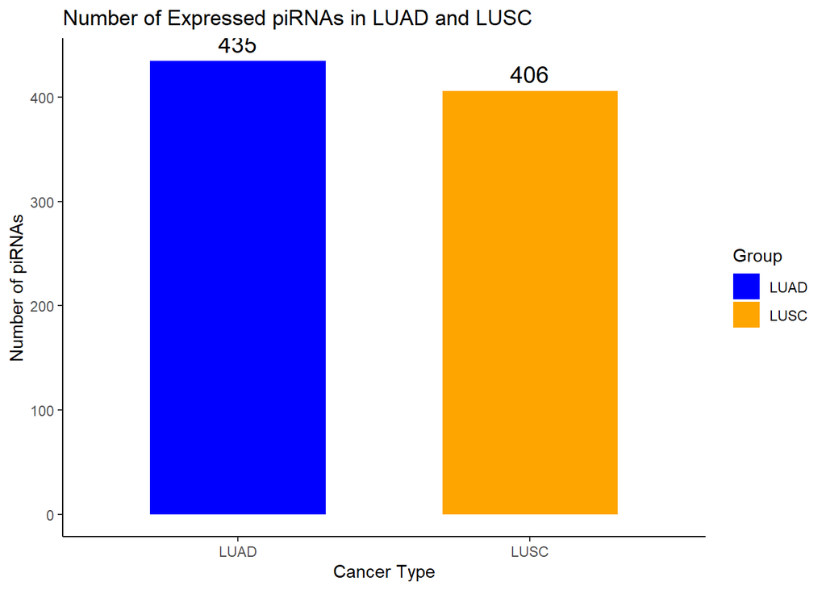

```r
# 1. Create data frame for bar chart
barchart <- data.frame(
  Group = c("LUAD", "LUSC"),
  piRNA_Count = c(435, 406)
)

# 2. Generate bar chart
ggplot(barchart, aes(x = Group, y = piRNA_Count, fill = Group)) +
  geom_bar(stat = "identity", width = 0.6) +
  labs(title = "Number of Expressed piRNAs in LUAD and LUSC",
       x = "Cancer Type", y = "Number of piRNAs") +
  theme_classic() +
  scale_fill_manual(values = c("LUAD" = "blue", "LUSC" = "orange")) +
  geom_text(aes(label = piRNA_Count), vjust = -0.5, size = 5) # Add labels to bars
```

### Pie Charts: Exclusive vs Shared piRNAs

[figure not shown]

```r
# 3. Define the total and exclusive piRNAs for LUAD, LUSC, and Fetal tissues
luad_total <- 435
lusc_total <- 406
fetal_total <- 437

luad_exclusive <- round(16.1 / 100 * luad_total)  # 70 piRNAs
lusc_exclusive <- round(17.5 / 100 * lusc_total)  # 71 piRNAs

# 4. Data frames for each pie chart
data_luad <- data.frame(
  Category = c("Shared with ANL", "Exclusive to Tumor"),
  Count = c(luad_total - luad_exclusive, luad_exclusive)
)

data_lusc <- data.frame(
  Category = c("Shared with ANL", "Exclusive to Tumor"),
  Count = c(lusc_total - lusc_exclusive, lusc_exclusive)
)

# 5. Function to create pie chart
create_pie_chart <- function(data, title) {
  ggplot(data, aes(x = "", y = Count, fill = Category)) +
    geom_bar(stat = "identity", width = 1) +
    coord_polar(theta = "y") +
    theme_void() +
    labs(title = title) +
    geom_text(aes(label = Count), position = position_stack(vjust = 0.5), size = 5) +
    scale_fill_manual(values = c("Shared with ANL" = "#1f77b4", "Exclusive to Tumor" = "#ff7f0e"))
}

# 6. Create individual pie charts for LUAD and LUSC
p1 <- create_pie_chart(data_luad, "LUAD piRNA Distribution")
p2 <- create_pie_chart(data_lusc, "LUSC piRNA Distribution")

print(p1)
```

[figure not shown]

```r
print(p2)
```

## piRNAs in LUAD and LUSC

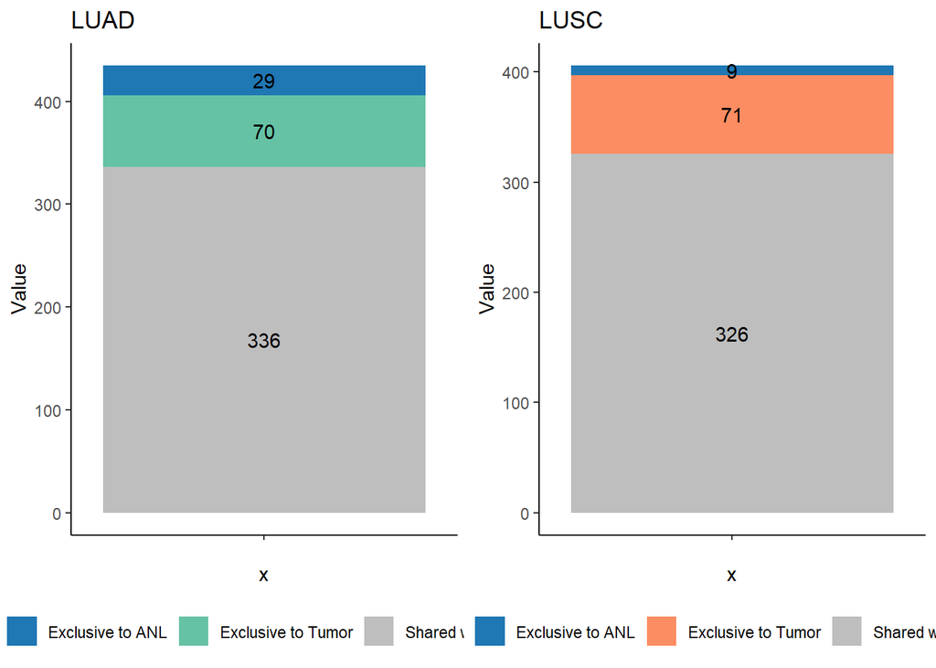

```r
# Function to create a stacked bar chart
create_bar_plot <- function(data, title) {
  ggplot(data, aes(x = "", y = Value, fill = Category)) +
    geom_bar(stat = "identity", width = 1, position = "stack") +
    scale_fill_manual(values = data$Color) +
    labs(title = title) +
    theme_classic() +
    theme(
      legend.title = element_blank(),
      legend.position = "bottom"
    ) +
    geom_text(aes(label = Value), position = position_stack(vjust = 0.5), color = "black")
}

# Data for LUAD
data_LUAD <- data.frame(
  Category = c("Shared with ANL", "Exclusive to Tumor", "Exclusive to ANL"),
  Value = c(336, 70, 29),
  Color = c("#1f77b4", "#66c2a5", "gray")
)

# Data for LUSC
data_LUSC <- data.frame(
  Category = c("Shared with ANL", "Exclusive to Tumor", "Exclusive to ANL"),
  Value = c(326, 71, 9),
  Color = c("#1f77b4", "#fc8d62", "gray")
)

# Create the plots
luad_bar <- create_bar_plot(data_LUAD, "LUAD")
lusc_bar <- create_bar_plot(data_LUSC, "LUSC")

# Arrange the plots side by side
combined_plot <- grid.arrange(luad_bar, lusc_bar, ncol = 2)
```

```r
# Save the combined plot
ggsave(filename = "stacked_bar.png", plot = combined_plot, dpi = 600, width = 10, height = 10)
```

### Overall piRNA Distribution (LUAD, LUSC, and Fetal Tissues)

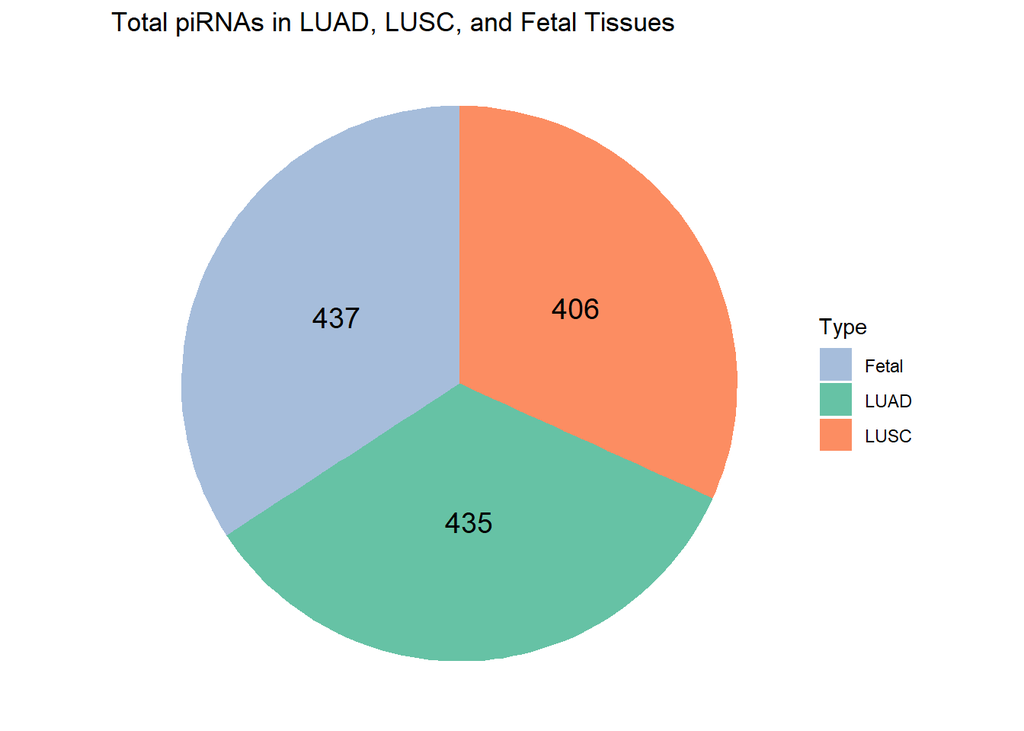

```r
# 7. Combined data for total piRNAs
data_combined <- data.frame(
  Type = c("LUAD", "LUSC", "Fetal"),
  Total_piRNAs = c(luad_total, lusc_total, fetal_total)
)

# 8. Overall summary pie chart
p3 <- ggplot(data_combined, aes(x = "", y = Total_piRNAs, fill = Type)) +
  geom_bar(stat = "identity", width = 1) +
  coord_polar(theta = "y") +
  theme_void() +
  labs(title = "Total piRNAs in LUAD, LUSC, and Fetal Tissues") +
  geom_text(aes(label = Total_piRNAs), position = position_stack(vjust = 0.5), size = 5) +
  scale_fill_manual(values = c("LUAD" = "#66c2a5", "LUSC" = "#fc8d62", "Fetal" = "#a6bddb" ))

# show plot
p3
```

# **piRNA Expression Across Different Groups**

### Introduction

This analysis aims to explore the piRNAs that are uniquely expressed in different biological groups: **ANL**, **Tumor (LUAD and LUSC)**, and **Fetal**. The UpSet plot will illustrate the intersections of piRNA expression between these groups, highlighting the specific piRNAs expressed in each group, as well as shared piRNAs across multiple groups. The groups of interest are:

- **ANL**: A set of piRNAs exclusively expressed in ANL (from LUAD or LUSC).
- **Tumor (LUAD and LUSC)**: piRNAs uniquely expressed in Lung Adenocarcinoma (LUAD) and Squamous Cell Lung Cancer (LUSC).
- **Fetal**: piRNAs exclusively expressed in fetal tissues.
- The plot will also explore the co-expressions, for example, between fetal and ANL, LUAD and fetal, and so on.

### Step 1: Defining Intersection Quantities

```r
# Quantities representing the number of piRNAs in each intersection
quantities <- c(
  LUAD = 16,                # Exclusively expressed in LUAD
  fetal = 361,              # Exclusively expressed in fetal tissue
  LUSC = 9,                 # Exclusively expressed in LUSC
  ANL = 27,                 # Exclusively expressed in ANL
  fetal_ANL = 1,            # Shared between fetal and ANL
  LUAD_LUSC = 9,            # Shared between LUAD and LUSC
  LUAD_fetal = 22,          # Shared between LUAD and fetal
  LUAD_LUSC_fetal = 22,     # Shared between LUAD, LUSC, and fetal
  LUSC_fetal = 25,          # Shared between LUSC and fetal
  LUSC_fetal_ANL = 6,       # Shared between LUSC, fetal, and ANL
  LUAD_ANL = 1              # Shared between LUAD and ANL
)
```

### Step 2: Creating the Binary Intersection Data Frame

```r
# Create a binary dataframe for the intersections
intersections_df <- data.frame(
  LUAD = rep(0, sum(quantities)),
  LUSC = rep(0, sum(quantities)),
  fetal = rep(0, sum(quantities)),
  ANL = rep(0, sum(quantities))
)

# Assigning 1s to the respective intersections
intersections_df[1:quantities["LUAD"], "LUAD"] <- 1  # Exclusively LUAD
intersections_df[(quantities["LUAD"] + 1):(quantities["LUAD"] + quantities["LUSC"]), "LUSC"] <- 1  # Exclusively LUSC
intersections_df[(quantities["LUAD"] + quantities["LUSC"] + 1):(quantities["LUAD"] + quantities["LUSC"] + quantities["fetal"]), "fetal"] <- 1  # Exclusively fetal
intersections_df[(quantities["LUAD"] + quantities["LUSC"] + quantities["fetal"] + 1):(quantities["LUAD"] + quantities["LUSC"] + quantities["fetal"] + quantities["ANL"]), "ANL"] <- 1  # Exclusively ANL

# Adding shared intersections
intersections_df[(quantities["LUAD"] + quantities["LUSC"] + quantities["fetal"] + quantities["ANL"] + 1):(quantities["LUAD"] + quantities["LUSC"] + quantities["fetal"] + quantities["ANL"] + quantities["fetal_ANL"]), c("fetal", "ANL")] <- 1
intersections_df[(quantities["LUAD"] + quantities["LUSC"] + quantities["fetal"] + quantities["ANL"] + quantities["fetal_ANL"] + 1):(quantities["LUAD"] + quantities["LUSC"] + quantities["fetal"] + quantities["ANL"] + quantities["fetal_ANL"] + quantities["LUAD_LUSC"]), c("LUAD", "LUSC")] <- 1
intersections_df[(quantities["LUAD"] + quantities["LUSC"] + quantities["fetal"] + quantities["ANL"] + quantities["fetal_ANL"] + quantities["LUAD_LUSC"] + 1):(quantities["LUAD"] + quantities["LUSC"] + quantities["fetal"] + quantities["ANL"] + quantities["fetal_ANL"] + quantities["LUAD_LUSC"] + quantities["LUAD_fetal"]), c("LUAD", "fetal")] <- 1
intersections_df[(quantities["LUAD"] + quantities["LUSC"] + quantities["fetal"] + quantities["ANL"] + quantities["fetal_ANL"] + quantities["LUAD_LUSC"] + quantities["LUAD_fetal"] + 1):(quantities["LUAD"] + quantities["LUSC"] + quantities["fetal"] + quantities["ANL"] + quantities["fetal_ANL"] + quantities["LUAD_LUSC"] + quantities["LUAD_fetal"] + quantities["LUAD_LUSC_fetal"]), c("LUAD", "LUSC", "fetal")] <- 1
intersections_df[(quantities["LUAD"] + quantities["LUSC"] + quantities["fetal"] + quantities["ANL"] + quantities["fetal_ANL"] + quantities["LUAD_LUSC"] + quantities["LUAD_fetal"] + quantities["LUAD_LUSC_fetal"] + 1):(quantities["LUAD"] + quantities["LUSC"] + quantities["fetal"] + quantities["ANL"] + quantities["fetal_ANL"] + quantities["LUAD_LUSC"] + quantities["LUAD_fetal"] + quantities["LUAD_LUSC_fetal"] + quantities["LUSC_fetal"]), c("LUSC", "fetal")] <- 1
intersections_df[(quantities["LUAD"] + quantities["LUSC"] + quantities["fetal"] + quantities["ANL"] + quantities["fetal_ANL"] + quantities["LUAD_LUSC"] + quantities["LUAD_fetal"] + quantities["LUAD_LUSC_fetal"] + quantities["LUSC_fetal"] + 1):(quantities["LUAD"] + quantities["LUSC"] + quantities["fetal"] + quantities["ANL"] + quantities["fetal_ANL"] + quantities["LUAD_LUSC"] + quantities["LUAD_fetal"] + quantities["LUAD_LUSC_fetal"] + quantities["LUSC_fetal"] + quantities["LUSC_fetal_ANL"]), c("LUSC", "fetal", "ANL")] <- 1
intersections_df[(quantities["LUAD"] + quantities["LUSC"] + quantities["fetal"] + quantities["ANL"] + quantities["fetal_ANL"] + quantities["LUAD_LUSC"] + quantities["LUAD_fetal"] + quantities["LUAD_LUSC_fetal"] + quantities["LUSC_fetal"] + quantities["LUSC_fetal_ANL"] + 1):(quantities["LUAD"] + quantities["LUSC"] + quantities["fetal"] + quantities["ANL"] + quantities["fetal_ANL"] + quantities["LUAD_LUSC"] + quantities["LUAD_fetal"] + quantities["LUAD_LUSC_fetal"] + quantities["LUSC_fetal"] + quantities["LUSC_fetal_ANL"] + quantities["LUAD_ANL"]), c("LUAD", "ANL")] <- 1
```

### Step 3: Generating the UpSet Plot

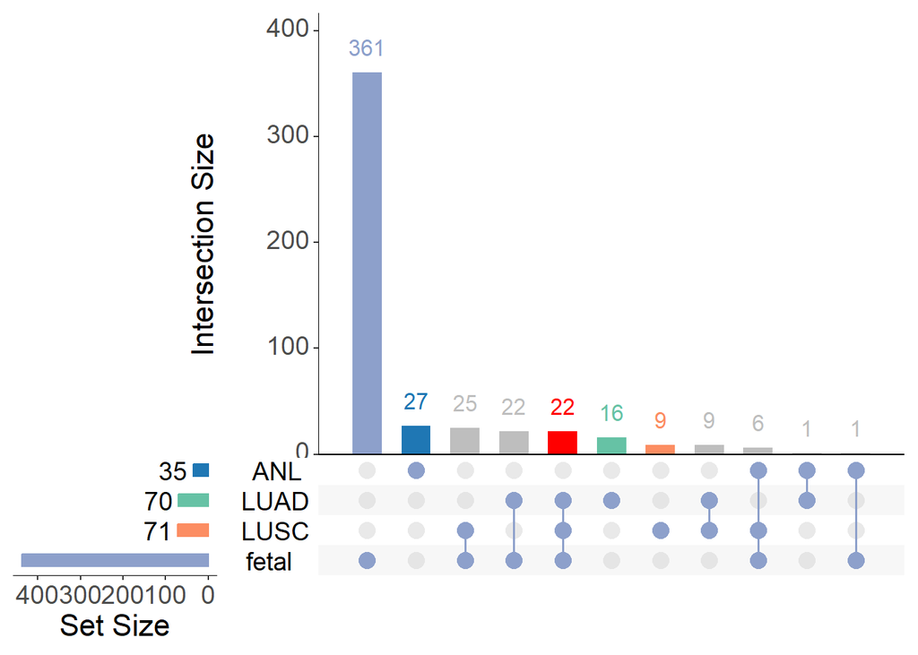

```r
# Generate the UpSet plot

suppressWarnings(
  UpSetR::upset(
    intersections_df,
    sets = c("LUAD", "LUSC", "fetal", "ANL"),
    sets.bar.color = c("#8da0cb", "#fc8d62", "#66c2a5", "#1f77b4"),  # Color palette for sets
    order.by = "freq",  # Order by frequency of intersections
    point.size = 4,
    set_size.show = TRUE,
    text.scale = 2,
    main.bar.color = c("#8da0cb", "#1f77b4", "gray", "gray", "red", "#66c2a5", "#fc8d62", "gray", "gray", "gray", "gray"),
    matrix.color = c("#8da0cb", "#1f77b4", "gray", "gray", "red", "#66c2a5", "#fc8d62", "gray", "gray", "gray", "gray")
  )
)
```

### Conclusion

The UpSet plot provides an effective visualization of the piRNAs that are expressed in the LUAD, LUSC, fetal, and ANL groups, allowing us to better understand the unique and shared piRNA expressions across these tissues. The resulting graphic can be used to identify potential biomarkers or therapeutic targets in lung cancer and fetal development.